# MULTILOOPS IN SURFACES

This module deals with multiloops in a surface of genus g>0 and 1 puncture.

The surface of genus g>0 (with 1 puncture), is obtained by gluing a (truncated) 4g-gon. The identification pattern of the 4g-gon is encoded by a chord diagram : a cyclic word in which each letter appears twice (lower and upper case). For instance 'abABcdCD...' is the standard chodiag for a closed surface. A chord diagram for a sphere with k-holes is 'aAbBcCdD...'.

A loop is given from its cutting sequence wrt the chord diagram, or equivalently as a product in the standard presentation of the fundamental group, it is thus encoded as a linear word in the letters a, A, b, B, etc. A multiloop is a collection of loops, encoded as a sequence of loops.

The main functions of this module are :

multicurve_basis_decomposition : list of str --> list of list of str Given a multiloop in a closed surface minus 0 or 1 point, it decomposes its trace function as a linear combination of multicurves.

```python
import numpy as np
import matplotlib.pyplot as plt
# import CourbeSimples_AlgosPropres as cs
```

# Multicurve Basis Decomposition

The main function of this section is multicurve_basis_decomposition. Given a multiloop in a closed surface minus 0 or 1 point, it decomposes its trace function as a linear combination of multicurves.

It relies on smooth_an_intersection and proceeds inductively.

The function smooth_an_intersection relies on linked_words The function linked_words relies on on linked_quadruples

```python
"""
    The function cyclorder(x,y,z) takes three elements x, y, z
    in a (cyclic) poset and returns their cyclic order 1,0,-1

    The function across(W,Z,cycle) returns 2,1,0,-1,-2 which equals
    double the symplectic intersection number of the chords W and Z
    taken in this order.

"""

def cyclorder(x,y,z):
    return np.sign((z-y)*(z-x)*(y-x))

def across(W, Z, cycle):
    pu = cycle.index(W[0])
    pv = cycle.index(W[1])
    px = cycle.index(Z[0])
    py = cycle.index(Z[1])
    return(cyclorder(pu,px,pv)-cyclorder(pu,py,pv))
```

```python
print(across(('a', 'B'), ('b', 'B'), 'aAbB')) # tangent
print(across(('a', 'A'), ('b', 'B'), 'abAB')) # crossing
print(across(('a', 'A'), ('b', 'B'), 'aAbB')) # disjoint
```

```
1
2
0
```

```python
"""
    The function is_linked_pair returns 1,0,-1 depending on whether
    w1[s1-1], w2[s2-1], w1[s1:], w2[s2:] are linked on the boundary
    the linking being defined with respect to the cycle.

    This corresponds to the relative position of the axes associated to
    the infinite linear words with ...+w1+(w1[:s1]) extending to the left
    and w1[s1:]+w1+... extending to the right.

    The answer is 1 if they cross, -1 if they are disjoint, 0 if tangent.
    (This can be determined by looking only length(l1)+length(l2) letters
    since u^infty = v^infty iff uv = vu.)
"""


def is_linked_pair(word1, word2, s1, s2, cycle):

    w1s = word1[s1-1].swapcase()
    w2s = word2[s2-1].swapcase()

    if w1s == w2s :
        return 0

    k = 0
    while((word1[(s1+k)%len(word1)] == word2[(s2+k)%len(word2)]) &\
        (k <= (len(word1)+len(word2)))):
        k += 1

    w1t = word1[(s1+k)%len(word1)]
    w2t = word2[(s2+k)%len(word2)]

    return abs(across((w1s, w1t), (w2s, w2t), cycle))-1
```

```python
word1 = 'abbababab'
word2 = 'abbba'

print(is_linked_pair(word1, word2, 0, 0, 'aABb')) # linked
# print(is_linked_pair(word1, 'abbba', chordiag = 'baAB'))
# print(is_linked_pair(word1, 'abbba', chordiag = 'BbaA'))

print(is_linked_pair(word1, word2, 0, 0, 'aAbB')) # unlinked
print(is_linked_pair(word1, word2, 0, 0, 'abAB')) # unlinked
print(is_linked_pair(word1, word2, 0, 0, 'aBAb')) # unlinked
```

```
1
-1
-1
-1
```

```python
word = 'abaBba'
x = word[-1].swapcase()
print(x, word)
```

```
A abaBba
```

```python
"""
    The function find_intersection inspects linear cyclic permutations of words
    and returns the first pair of indices (s1, s2) such that :
    w1[s1-1], w2[s2-1], w1[s1:], w2[s2:] are linked on the boundary
    the linking being defined with respect to the cycle.
    If the loops do not intersect it returns None.

"""


def find_intersection(word1, word2, cycle):

    for s1 in range(len(word1)):
        for s2 in range(len(word2)):
            if is_linked_pair(word1, word2, s1, s2, cycle)==1:
                return(s1, s2)

    return(None)
```

```python
word1 = 'babbababa' # 'abbababab'
word2 = 'abbba'

s1, s2 = find_intersection(word1, word2, 'abBA')
print(s1,s2)
sword1 = word1[s1:]+word1[:s1]
sword2 = word2[s2:]+word2[:s2]
print(sword1, sword2)
```

```
0 3
babbababa baabb
```

```python
"""Testing behaviour of booleans and exceptions"""

print(None==np.int(-1), None ==-1 , None == False, None == None, not None, '\n')

if not None:
    print('this')

if [] :
    print('something')

try :
    (x,y)=None
except TypeError:
        print('This would have raised an exception of the \
        \n TypeError: cannot unpack non-iterable NoneType object')
```

```
False False False True True

this
This would have raised an exception of the
 TypeError: cannot unpack non-iterable NoneType object
```

```python
"""
    The function find_intersecting_loops finds two intersecting loops in the multiloop
    and returns the indices of the loops followed by the indices of the linked pairs.
"""

def find_intersecting_loops(multiloop, cycle):
    for i, loopi in enumerate(multiloop):
        for j, loopj in enumerate(multiloop):
            fi = find_intersection(loopi, loopj, cycle)
            if not fi :
                continue
            else :
                return((i,j), fi)
    return(None)
```

```python
find_intersecting_loops(['abb','ab'], 'abAB')
```

```
((0, 1), (2, 1))
```

```python
"""
    The function reduce(word) returns the reduced cyclic representative
    in the free group generated by the letters of the word.

    The function inverse(word) returns the inverse of an element,
    in the free group on small letters whose inverse are capitals.
"""

def simplification(word):
    for p, char in enumerate(word):
        if word[p-1] == char.swapcase():
            return(p)
    return None

def reduce(word):
    p = simplification(word)
    if p == None:
        return word
    elif p == 0:
        return reduce(word[1:-1])
    else:
        return reduce(word[(p+1):]+word[:(p-1)])

def inverse(word):
    return word[::-1].swapcase()
```

```python
print(simplification('aabbaaA'))
print(reduce('aAbbBA'))
```

```
0
Ab
```

```python
"""
    The function smooth_intersection takes a multiloop : list of str
    along with the cycle pattern, and returns a list of list of str
    with two new multiloops obtained by smoothing an intersection.

    If there is no intersection, the first line raises a TypeError.
    This TypeError will be catched in the multicurve_basis_decomposition.
"""

def smooth_intersection(multiloop, cycle):

    ((i,j), (si, sj)) = find_intersecting_loops(multiloop, cycle)

    if i==j :
        loop = multiloop.pop(i)
        si, sj = min(si,sj), max(si,sj)

        sloop0 = loop[si:sj]
        sloop2 = loop[sj:] + loop[:si]
        sloop1 = sloop0 + inverse(sloop2)

        sm1 = multiloop + [reduce(sloop1)]
        sm2 = multiloop + [reduce(sloop0), reduce(sloop2)]

    else :
        loopi = multiloop[i]
        loopj = multiloop[j]
        del multiloop[max(i,j)]
        del multiloop[min(i,j)]

        cloopi = loopi[si:]+loopi[:si]
        cloopj = loopi[sj:]+loopj[:sj]

        sloop1 = cloopi + cloopj
        sloop2 = cloopi + inverse(cloopj)

        sm1 = multiloop + [reduce(sloop1)]
        sm2 = multiloop + [reduce(sloop2)]

    return [sm1, sm2]
```

```python
smooth_intersection(['abbbabaabaab'], 'abAB')
```

```
[['bbabaBAA'], ['abbbaba', 'abaab']]
```

```python
x, y = 1,2
x, y = max(x, y), min(x, y)
print(x,y)
```

```
2 1
```

```python
"""
    The function multicurve_basis_decomposition : list of str  --> list of list of str
    takes a multiloop in a genus g surface minus 1 point (a cycle of 2g-identifications)
    and decomposes its trace function in the linear basis of multicurves.
"""

def multicurve_basis_decomposition(multiloop, cycle):

    multiloops = [multiloop]
    multicurves = []

    while multiloops:
        multiloopop = multiloops.pop()
        try:
            smoothings = smooth_intersection(multiloopop, cycle)
            multiloops.extend(smoothings)
        except TypeError:
            multicurves.append(multiloopop)

    return multicurves
```

```python
multicurve_basis_decomposition(['abbbabaabaab'], 'abAB')
```

```
[['bbaba', 'baBA'],
 ['bA'],
 ['ab', 'ab', 'ab', 'baba'],
 ['ab', 'ab', 'abABAB'],
 ['ab', 'ABAB'],
 ['ab', 'baba'],
 ['abABAB'],
 ['abababa'],
 ['ababaabABAB'],
 ['babaBA', 'Ab'],
 ['babaBABa']]
```

# SUPPLEMENTARY FUNCTIONS

```python
"""
    The function list_linked_pairs returns the list of all such pairs.
    The function intersection number computes the number of linked pairs.
    The function intersection_matrix returns the intersection matrix of a multiloop.
"""

def list_linked_pairs(word1, word2, cycle):

    pairs = []

    for s1 in range(len(word1)):
        for s2 in range(len(word2)):
            if is_linked_pair(word1, word2, s1, s2, cycle)==1:
                pairs.append((s1, s2))

    return(pairs)

def intersection_number(word1, word2, cycle):
    return len(list_linked_pairs(word1, word2, cycle))

def intersection_matrix(multiloop, cycle):
    nloops = len(multiloop)
    mat = np.zeros(nloops, dtype=int)
    for i in range(nloops):
        for j in range(nloops):
            mat[i,j]=intersection_number(multiloop[i], multiloop[j], cycle)
    return mat
```

```python
print(list_linked_pairs('abbba', 'babbababa', 'abAB'))
print(list_linked_pairs('abbba', 'babbababa', 'abBA'))
print(intersection_number('BBABAbABABA', 'BBABAbABABA','abBA'))
print(intersection_number('bABabABABa', 'bABabABABa','abBA'))
```

```
[(0, 3), (2, 0), (2, 5), (2, 7)]
[(0, 1), (0, 4), (0, 6), (0, 8), (1, 1), (1, 3), (1, 4), (1, 6), (1, 8), (2, 2), (3, 0), (3, 2), (3, 5), (3, 7), (4, 0), (4, 2), (4, 5), (4, 7)]
36
18
```

```python
print(intersection_number('abABAB', 'abABAB','abBA'))
print(intersection_number('ABBABAB', 'ABBABAB','abBA'))
```

```
8
24
```

```python
"""
    The function is_primitive returns True if the word is primitive
    and the primitive root together with the power if not.
"""

def is_primitive(loop):
    for k in range(1,len(loop)):
        if loop[k:]+loop[:k] == loop:
            return(loop[:k], len(loop)//k)
    return True

"""
    The function perm_cycle of an iterable returns
    the list of all its cyclic permutations.
"""

def perm_cycle(word):
    return ["".join([word[i - j] for i in range(len(word))]) \
            for j in range(len(word),0,-1)]

"""
    The function is_puncture returns the boolean telling whether
    the loop is a cyclic permutation of the cycle or its inverse
    (and thus encircles the puncture once)
"""

def is_puncture(loop, cycle):
    return loop in perm_cycle(cycle) + perm_cycle(inverse(cycle))
```

```python
print(is_primitive('abcabc'))
print(perm_cycle('abcdef'))
print(is_puncture('baBA', 'abAB'))
```

```
('abc', 2)
['abcdef', 'bcdefa', 'cdefab', 'defabc', 'efabcd', 'fabcde']
True
```

# Chordiagrams

```python
"""
    The function chordiag computes the chord diagram of a multiloop.
    The function chordiag of a multiloop
"""

def chordiag_loop(loop, cycle):
    n = len(loop)
    cycloops = perm_cycle(loop)
    pass

def chordiag_multiloop(loop, cycle):
    n = len(loop)
    cycloops = perm_cycle(loop)
    pass
```

# THE PUNCTURED TORUS

```python
""" !!! IN THIS SECTION THE CYCLE IS 'abAB' !!! """
```

```
" !!! IN THIS SECTION THE CYCLE IS 'abAB' !!! "
```

```python
"""
    The function pentore returns the pair of integers corresponding to the slope
    of the loop in the once-punctured torus (assuming it has no intersections).
"""

def pentore(loop):
    na=loop.count("a")
    nb=loop.count("b")
    nA=loop.count("A")
    nB=loop.count("B")
    return (na-nA,nb-nB)
```

```python
pentore('ababbbABAB')
```

```
(0, 2)
```

```python
"""
    The function param_multicurve returns ((sa,sb)), no, n0) where
    n0 is the number of trivial loops in the multicurve
    no is the number of boundary components in the multicurve
    sa,sb is the total slope of the non-boundary components of 'multicurve'.
"""

def param_multicurve(multicurve, cycle = 'abAB'):
    n0, no = 0,0
    sa, sb = 0,0

    for curve in multicurve:
        if not curve:
            n0+=1
        elif is_puncture(curve, cycle):
            no+=1
        else:
            na,nb = pentore(curve)
            sa+=np.sign(nb)*na
            sb+=np.abs(nb)

    return((sa,sb), no, n0)
```

```python
param_multicurve(['ab', 'abab', '', 'abAB'])
```

```
((3, 3), 1, 1)
```

```python
"""
    The function affiche_loop takes a multiloop on the once-punctured torus and
    prints the Newton polygon given by its decomposition in the multicurve basis.
"""


def NewPol_multiloop(multiloops, cycle='abAB'):

    multicurves = multicurve_basis_decomposition(multiloops, cycle)

    nuage_X=[]
    nuage_Y=[]

    for multicurve in multicurves:
        (sa,sb) = param_multicurve(multicurve, cycle)[0]
        nuage_X.append(sa)
        nuage_Y.append(sb)

    plt.scatter(nuage_X,nuage_Y)
    plt.show()

    return list(zip(nuage_X, nuage_Y))
```

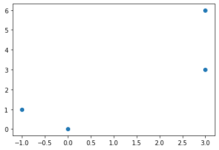

```
[(-1, 1), (3, 3), (3, 6), (0, 0)]
```

```python
NewPol_multiloop(['aababbabbbababa'])
```